# Project Report - Deforestation

# Deforestation and carbon balance in Southern Virginia, U.S. between 1990 and 2000

## Introduction

Forest is the largest terrestrial carbon sink stabilizing carbon storage on Earth. Forest also plays a fundamental role in regulating global climate, securing watershed health conditions, sheltering biological diversity, and providing other ecosystem services (Potapov et al., 2017; Hansen et al., 2013). Although forest performs irreplaceable functions in both ecosystem and carbon cycle, about 7-11 million square kilometers of natural forests have been deforested through agricultural expansion and timber harvest during the past 300 years (Foley et al., 2005). Deforestation can affect a wide range of ecological functions, including carbon stocks and biomass accumulations. Forest ecosystem carbon stock, which is closely related to above ground woody biomass, stores carbon sequestered from the atmosphere. In this study, we chose six counties in Southern Virginia to understand the connection among deforestation, carbon, and biomass because forest harvesting events are particularly common in forestland of Virginia. Much more carbon stocks and biomass are removed from this region than the Northern, Rockies, and Southern pacific coast regions (Masek et al., 2011). Specifically, we intend to understand 1) how many forests are deforested in these six counties between 1990 and 2000; 2) how carbon stocks are affected from deforestation; 3) How aboveground woody biomass (AGB) are affected from deforestation.

## Data & Methods

### 2.1 Quantifying forest harvest between 1990 and 2000 (Jianing)

To explore the forest disturbance across our study region, we used the North American Forest Dynamics (NAFD) products derived from Landsat images with a nominal spatial 30 m and forest disturbances mapped at an annual time step. Each annual map has classified pixels showing water, no forest cover, forest cover and forest disturbance that occurred in that year. In our project, we used both raster, vector data and tiff images, produced cartographic images and tables and saved our results into png format. So, we loaded the packages: “ geospaar”, “dplyr”, “rgdal”, “ tiff”, “ggplot2”, “here” and “gridExtra”. we mainly used the functions “st_read”, “st_write”, “raster”, “st_transform”, “crop”, “raster::mask” , “rasterize” and “resample” in our data pre-processing stage. In the analysis step, we used the “zonal”, “plot_noaxes”, “resample”,” tableGrob”, “grid.arrange” functions. While, in the result part, we used “here”, “writeRaster”, “png”, “dev.off “, “knitr::include_graphics” functions.

### 2.2 Comparing forest carbon stock change between 1990 and 2000 (Novak)

Forest Carbon Stocks and Fluxes After Disturbance, Southeastern USA, 1990-2010 (novak) We used Forest Carbon Stocks and Fluxes After Disturbance, Southeastern USA, 1990-2010 dataset to study the carbon stocks and fluxes. We specifically extracted two data files to study the carbon stocks and fluxes in the form of net ecosystem productivity (NEP) in 1990 and 2000. Data was then cropped and masked using a study area raster that we created based on our selection of 6 counties in Virginia. Functions like “resample” and “zonal” are then used to summarize the statistics of the amount of NEP and further compare the results in the two years. Other analyses on amount of NEP in harvested areas and undisturbed areas were also performed.

### 2.3. Comparing forest biomass change between 1990 and 2000 (Li)

Biomass data were extracted from the National Aboveground Biomass and Carbon Baseline Dataset (NBCD, Version 2) and Forest Carbon Stocks and Fluxes After Disturbance, Southeastern USA, 1990-2010 dataset. Biomass were compared between 1990 and 2000 for all forest land, the forest harvested land, and the undisturbed land in our study area. A variety of packages are used to pre-process raster and shapefiles and visualize datasets. Besides the packages mentioned in the sections above, I have also used rastervis, tmap, and mapview to visualize my data. Additionally, merge, full_join, and raster calculation are three functions that I haved used but not mentioned in the sections above.

## 3. Results

### 3.3 Forest biomass change between 1990 and 2000 (Li)

Figure 10-12 shows aboveground woody biomass (AGB) in 1990 and 2000 collected from two different datasets. The SE forest carbon stock dataset shows that the total AGB in 1990 and 2000 ranges from about 1 to 11 kg C per square meter. Differently, the NBCD dataset represents a much larger range of AGB estimates for our study area, about 0 to 32 kg C per square meter. One potential reason causing this distinct difference is due to different biomass measuring approaches.

In Figure 13, the biomass of total forest land is shown to be decreased from 1990 to 2000 because of frequent forest harvesting events in the study region. Since the NBCD dataset provides a much larger estimate of biomass which makes comparison impossible, we decide to ignore it. Figure 14 shows that Brunswick is the county that lost the highest amount of biomass from harvest events, followed by Sussex, Lunenburg, Mecklenburg, Dinwiddie, and Greensville. Figure 15 shows that Mecklenburg maintains the highest undisturbed biomass, followed by Brunswick, Dinwiddie, Lunenberg, Sussex, and Greensville.

#### 3.3.1 Data pre-processing

```r
library(geospaar)
library(rgdal)
library(dplyr)
library(ggplot2)
library(knitr)
library(deforestation)
library(tmap)
library(rasterVis)
library(mapview)
library(here)
```

```r
# install your own package 'deforestation', run these two lines every time after changing anything in your package.
#devtools::document()
#devtools::install()
#library(deforestation)

# Rewrite your branch and clear your large files in git history
# $ git filter-branch --force --tree-filter 'rm -rf data/' HEAD


# read study area's shapefile
# use relevant paths in the package, not full paths
studyarea <- system.file("extdata/VA_STUDYAREA.shp", package = "deforestation")
studyarea <- st_read(studyarea)
studyarea

# Dataset: NBCD V2 2000
## import raster (FIA ALD biomass)
path1 <- "C:/Users/Li/Desktop/geog_346/NBCD_MZ60_FIA_ALD_biomass/NBCD_MZ60_FIA_ALD_biomass.tif"
biomass1 <- raster(path1)
biomass1
plot(biomass1)

path2 <- "C:/Users/Li/Desktop/geog_346/NBCD_MZ59_FIA_ALD_biomass/NBCD_MZ59_FIA_ALD_biomass.tif"
biomass2 <- raster(path2)
biomass2
plot(biomass2, add = TRUE)

## Reproject study area shapefile
studyarea_nad83 <- st_transform(x = studyarea, crs = crs(biomass1))
studyarea_nad83
studyarea_nad83 <- studyarea_nad83 %>% select(-GEOID, -COUNTYNS, -LSAD, -CLASSFP, -MTFCC, -CSAFP, -CBSAFP, -METDIVFP, -FUNCSTAT, -ALAND, -AWATER, -INTPTLAT, -INTPTLON, -SHAPE_Leng, -SHAPE_Area)

st_write(obj = studyarea_nad83, dsn = file.path("inst/extdata/", "studyarea_nad83.shp"), delete_layer = TRUE)


## create a png file
#png("external/figures/studyarea_nad83.png", bg = "transparent", height = 4, width = 3, res = 300, units = "in")
## plot
par(mar = c(0, 0, 1, 0))
plot(st_geometry(studyarea_nad83), col = rainbow(n = nrow(studyarea_nad83)), main = "Study Area")
legend(x = "bottomright", pch = 15, col = rainbow(n = nrow(studyarea_nad83)), bty = "n", legend = studyarea_nad83$NAME)
## close and save the plot into the png file
#dev.off()

# tmap
#png("external/figures/studyarea_nad83_tmap.png", bg = "transparent", height = 4, width = 3, res = 300, units = "in")
tm_shape(studyarea_nad83) +
  tm_polygons(col = "MAP_COLORS", palette = "Pastel1")
#dev.off()

## Merge rasters
biomass_merge <- merge(biomass1, biomass2)
biomass_merge
plot(biomass_merge)

## crop raster
biomass_crop <- crop(x = biomass_merge, y = studyarea_nad83)
biomass_crop
plot(biomass_crop)
plot(st_geometry(studyarea_nad83), col = rgb(1, 1, 1, alpha = 0), add = TRUE)

## mask raster
biomass_clip <- raster::mask(x = biomass_crop, mask = studyarea_nad83)
plot(biomass_clip)

## write raster into a new tif and save it in extdata/
writeRaster(biomass_clip,
            filename = file.path("inst/extdata/","biomass_FIA_ALD_2000.tif"))
biomass_FIA_ALD2000 <- raster(
  file.path("inst/extdata/", "biomass_FIA_ALD_2000.tif")
  )

## kg/m2 = [Digital Number] / 10
biomass_FIA_ALD2000_kgC <- biomass_FIA_ALD2000/10

## save png file
#png("external/figures/biomass_FIA_ALD2000.png", bg = "transparent", height = 5, width = 5, res = 300, units = "in")
plot_noaxes(biomass_FIA_ALD2000_kgC, main = "Aboveground Live Dry Biomass 2000", legend.args = list(text = expression("Kg C m"^-2)))
#dev.off()


# Dataset: Forest Carbon Stocks and Fluxes After Disturbance, SE US
## import raster
path3 <- "C:/Users/Li/Desktop/geog_346/agb_1990.tif"
biomass3 <- raster(path3)
biomass3
plot(biomass3)

path4 <- "C:/Users/Li/Desktop/geog_346/agb_2000.tif"
biomass4 <- raster(path4)
biomass4
plot(biomass4)

## crop raster
biomass3_crop <- crop(x = biomass3, y = studyarea_nad83)
biomass3_crop
plot(biomass3_crop)
plot(st_geometry(studyarea_nad83), col = rgb(1, 1, 1, alpha = 0), add = TRUE)

biomass4_crop <- crop(x = biomass4, y = studyarea_nad83)
biomass4_crop
plot(biomass4_crop)

## mask raster
biomass3_clip <- raster::mask(x = biomass3_crop, mask = studyarea_nad83)
plot(biomass3_clip)

biomass4_clip <- raster::mask(x = biomass4_crop, mask = studyarea_nad83)
plot(biomass4_clip)

# write rasters into extdata/
writeRaster(biomass3_clip,
            filename = file.path("inst/extdata/", "agb1990.tif"))
agb1990 <- raster(
            file.path("inst/extdata/", "agb1990.tif")
            )

# unit converted from g to kg
agb1990_kgC <- agb1990 / 1000

#png("external/figures/agb1990.png", bg = "transparent", height = 5, width = 5, res = 300, units = "in")
plot_noaxes(agb1990_kgC, main = "Aboveground Woody Biomass 1990", legend.args = list(text = expression("kg C m"^-2)))
#dev.off()

# rastervis
png("external/figures/agb1990_rastervis.png", bg = "transparent", height = 5, width = 5, res = 300, units = "in")
levelplot(agb1990_kgC)
dev.off()

# mapview - cannot save to png
mapview(studyarea_nad83, alpha.regions = 0, legend = T) + mapview(agb1990_kgC)


# agb2000
writeRaster(biomass4_clip,
            filename = file.path("inst/extdata/", "agb2000.tif"))
agb2000 <- raster(
  file.path("inst/extdata/", "agb2000.tif")
  )
agb2000_kgC <- agb2000 / 1000
#png("external/figures/agb2000.png", bg = "transparent", height = 5, width = 5, res = 300, units = "in")
plot_noaxes(agb2000_kgC, main = "Aboveground Woody Biomass 2000", legend.args = list(text = expression("kg C m"^-2)))
#dev.off()

# rastervis
png("external/figures/agb2000_rastervis.png", bg = "transparent", height = 5, width = 5, res = 300, units = "in")
levelplot(agb2000_kgC)
dev.off()

# mapview
mapview(studyarea_nad83, alpha.regions = 0, legend = T) + mapview(agb2000_kgC)
```

#### 3.3.2 Table & bar graph: List total quantities of AGB (kg C m-2) of total forest area in 1990 and 2000, over six counties.

```r
# 1990
## create empty raster in study area's extent and fill in value
zonal_ras <- raster(x = extent(studyarea_nad83), crs = crs(studyarea_nad83), res = 30)
values(zonal_ras) <- 1:ncell(zonal_ras)
zonal_ras

## convert study area vector to raster
studyarea_nad83_ras <- studyarea_nad83 %>% rasterize(x = ., y = zonal_ras)
plot(studyarea_nad83_ras)

## zonal statistics
### resample studyarea_nad83_ras to the parameters of agb1990, so the extent matches between data.
studyarea_nad83_ras_rs <- resample(x = studyarea_nad83_ras, y = agb1990_kgC, method = "ngb")
plot(studyarea_nad83_ras_rs)
zonal_agb1990 <- zonal(x = agb1990_kgC, z = studyarea_nad83_ras_rs, fun = "sum")
zonal_agb1990

## convert list to data frame and change row/col names
zonal_agb1990_df <- as.data.frame(zonal_agb1990)
colnames(zonal_agb1990_df) <- c("Zone", "AGB of total forest land (Kg C m-2)")
rownames(zonal_agb1990_df) <- studyarea_nad83$NAME
zonal_agb1990_df  ## table

## bar graph
zonal_agb1990_df$Name <- studyarea_nad83$NAME

# 2000
studyarea_nad83_ras_rs2000 <- resample(x = studyarea_nad83_ras, y = agb2000_kgC, method = "ngb")
plot(studyarea_nad83_ras_rs2000)
zonal_agb2000 <- zonal(x = agb2000_kgC, z = studyarea_nad83_ras_rs2000, fun = "sum")
plot(zonal_agb2000)

zonal_agb2000_df <- as.data.frame(zonal_agb2000)
colnames(zonal_agb2000_df) <- c("Zone", "AGB of total forest land (Kg C m-2)")
rownames(zonal_agb2000_df) <- studyarea_nad83$NAME
zonal_agb2000_df

zonal_agb2000_df$Name <- studyarea_nad83$NAME

# 2000 NBCD FIA ALD dataset
studyarea_nad83_ras_rs2000 <- resample(x = studyarea_nad83_ras, y = biomass_FIA_ALD2000_kgC, method = "ngb")
zonal_NBCD2000 <- zonal(x = biomass_FIA_ALD2000_kgC, z = studyarea_nad83_ras_rs2000, fun = "sum")
plot(zonal_NBCD2000)

zonal_NBCD2000_df <- as.data.frame(zonal_NBCD2000)
colnames(zonal_NBCD2000_df) <- c("Zone", "AGB of total forest land (Kg C m-2)")
rownames(zonal_NBCD2000_df) <- studyarea_nad83$NAME
zonal_NBCD2000_df

zonal_NBCD2000_df$Name <- studyarea_nad83$NAME

# Join two dfs and create one bar graph
df <- full_join(x = zonal_agb1990_df, y = zonal_agb2000_df) %>% full_join(., zonal_NBCD2000_df)
df$year <- c("1990","1990" , "1990", "1990", "1990", "1990", "2000", "2000", "2000", "2000", "2000", "2000","2000", "2000", "2000", "2000", "2000", "2000")  # year column needs to be character, not numeric.

png("external/figures/bar_agb.png", bg = "transparent", height = 5, width = 8, res = 300, units = "in")
ggplot(data = df, aes(x = Name, y = `AGB of total forest land (Kg C m-2)`, fill = year)) +
  geom_bar(colour = "black", stat="identity", position = position_dodge2())+
  scale_fill_brewer(palette="Paired")+
  theme_classic()
dev.off()
```

#### 3.3.3 Table & bar graph: List lost quantities of AGB (kg C m-2) of harvested forest area between 1990 and 2000, over six counties.

```r
loss <- raster("C:/Users/Li/Desktop/geog_346/deforestation/inst/extdata/forest_loss.tif")

# rebuild loss extent to make it to match agb1990_kgC
loss_v2 <- raster(vals=values(loss), ext=extent(agb1990_kgC), crs=crs(agb1990_kgC), nrows=dim(loss)[1],ncols=dim(loss)[2])
loss_v2[loss_v2 == 0] <- NA  # set 0 to NA

# mask agb1990_kgC using the loss_v2
loss1990clip <- raster::mask(x = agb1990_kgC, mask = loss_v2)

# Resampling
studyarea_nad83_ras_loss1990 <- resample(x = studyarea_nad83_ras, y = loss1990clip, method = "ngb")

# Zonal statistics
zonal_loss1990clip <- zonal(x = loss1990clip, z = studyarea_nad83_ras_loss1990, fun = "sum")

# convert to data frame and create table
zonal_loss1990_df <- as.data.frame(zonal_loss1990clip)
colnames(zonal_loss1990_df) <- c("Zone", "AGB of harvested forest land (Kg C m-2)")
rownames(zonal_loss1990_df) <- studyarea_nad83$NAME
zonal_loss1990_df

# Add name column to data frame
zonal_loss1990_df$Name <- studyarea_nad83$NAME

# Bar graph - harvested agb between 1990 and 2000
png("external/figures/bar_agb_harvested.png", bg = "transparent", height = 5, width = 8, res = 300, units = "in")
ggplot(data = zonal_loss1990_df, aes(x = Name, y = `AGB of harvested forest land (Kg C m-2)`, fill = Name)) +
  geom_bar(colour = "black", stat="identity")+
  scale_fill_brewer(palette="Set2")+
  theme_classic()
dev.off()
```

#### 3.3.4 Table & bar graph: List total quantities of AGB (kg C m-2) of undisturbed forest area between 1990 and 2000, over six counties.

```r
# read raster
undisturbed <- raster("C:/Users/Li/Desktop/geog_346/deforestation/inst/extdata/forest_nondisturbances.tif")

# rebuild raster to match extent of agb raster, and set 0 to na
undisturbed_v2 <- raster(vals=values(undisturbed), ext=extent(agb1990_kgC), crs=crs(agb1990_kgC), nrows=dim(undisturbed)[1],ncols=dim(undisturbed)[2])
undisturbed_v2[undisturbed_v2 == 0] <- NA  # set 0 to NA

# masking
Undisturbed1990clip <- raster::mask(x = agb1990_kgC, mask = undisturbed_v2)

# resampling
studyarea_nad83_ras_undisturb1990 <- resample(x = studyarea_nad83_ras, y = Undisturbed1990clip, method = "ngb")

# zonal statistics
zonal_undisturb1990clip <- zonal(x = Undisturbed1990clip, z = studyarea_nad83_ras_undisturb1990, fun = "sum")

# convert to data frame and create table
zonal_undisturb1990_df <- as.data.frame(zonal_undisturb1990clip)
colnames(zonal_undisturb1990_df) <- c("Zone", "AGB of undisturbed forest land (Kg C m-2)")
rownames(zonal_undisturb1990_df) <- studyarea_nad83$NAME
zonal_undisturb1990_df

zonal_undisturb1990_df$Name <- studyarea_nad83$NAME

# Bar graph - Undisturbed agb between 1990 and 2000
png("external/figures/bar_agb_undisturbed.png", bg = "transparent", height = 5, width = 8, res = 300, units = "in")
ggplot(data = zonal_undisturb1990_df, aes(x = Name, y = `AGB of undisturbed forest land (Kg C m-2)`, fill = Name)) +
  geom_bar(colour = "black", stat="identity")+
  scale_fill_brewer(palette="Set2")+
  theme_classic()
dev.off()
```

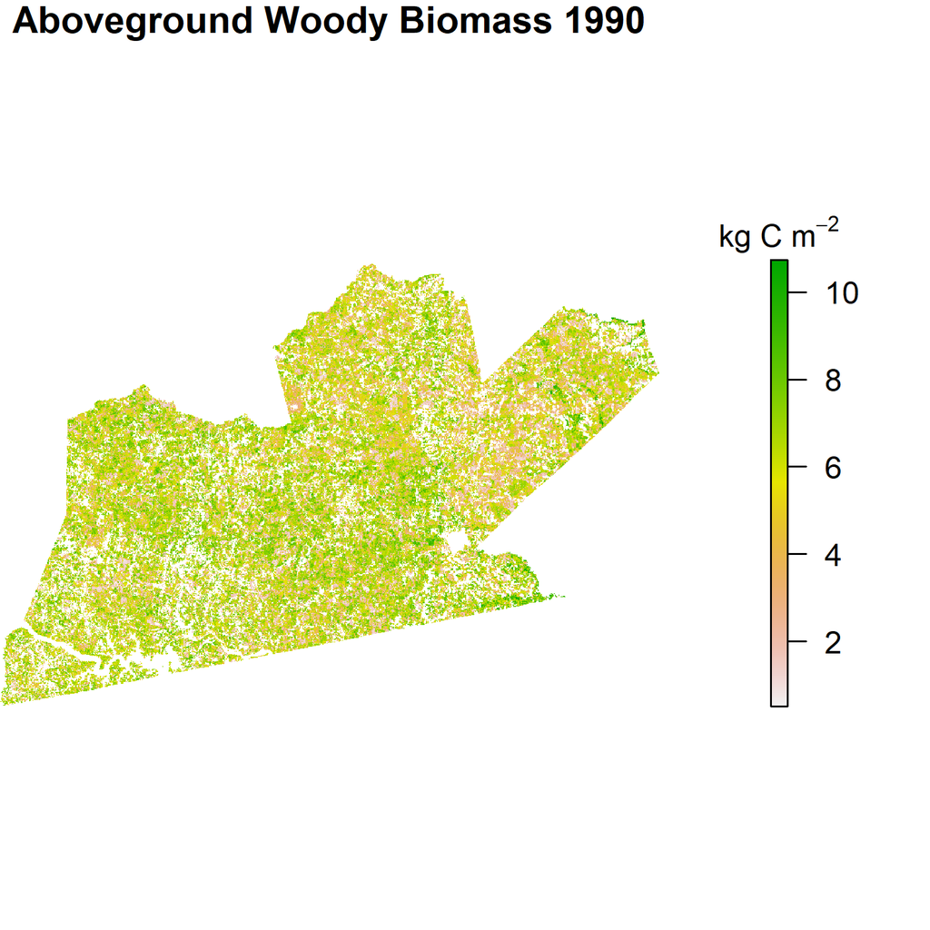

```r
# Figure 10: Aboveground woody biomass 1990 map. (SE forest carbon stock dataset).
knitr::include_graphics(here('external/figures/agb1990.png'))
```

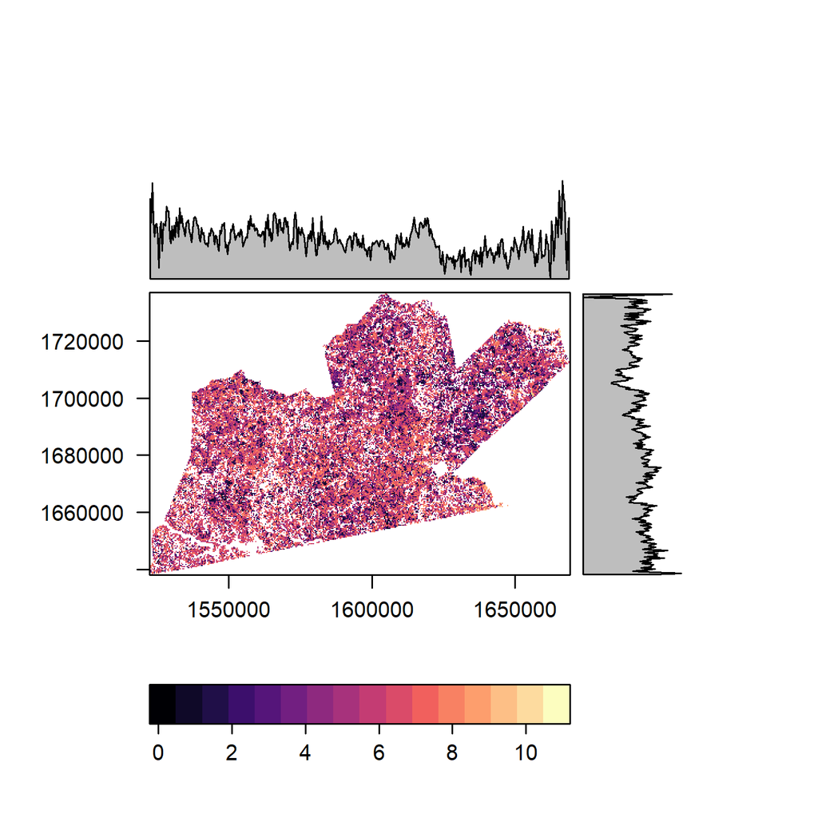

```r
knitr::include_graphics(here('external/figures/agb1990_rastervis.png'))
```

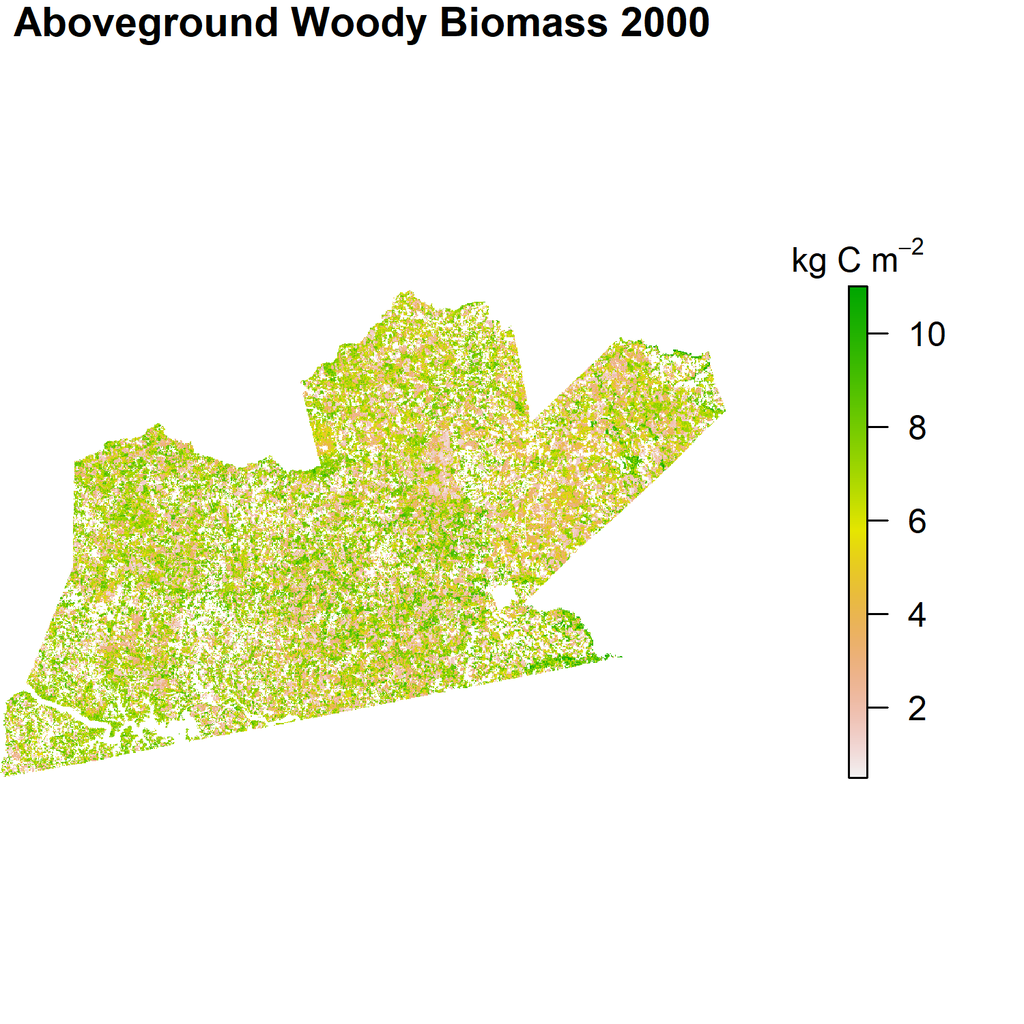

```r
# Figure 11: Aboveground woody biomass 2000 map. (SE forest carbon stock dataset).
knitr::include_graphics(here('external/figures/agb2000.png'))
```

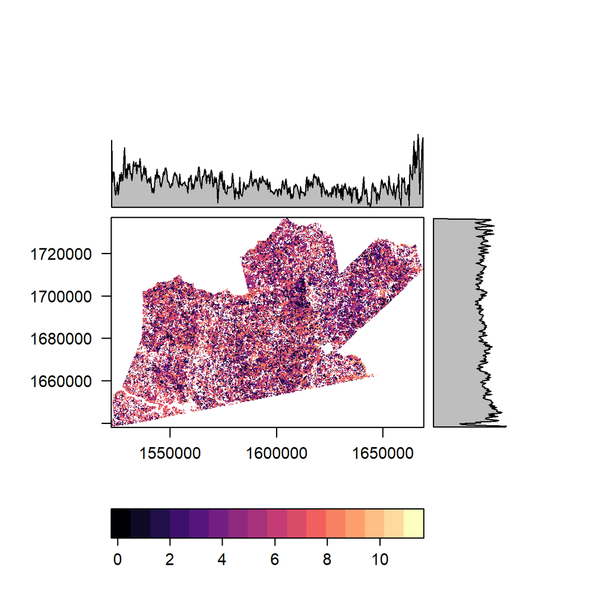

```r
knitr::include_graphics(here('external/figures/agb2000_rastervis.png'))
```

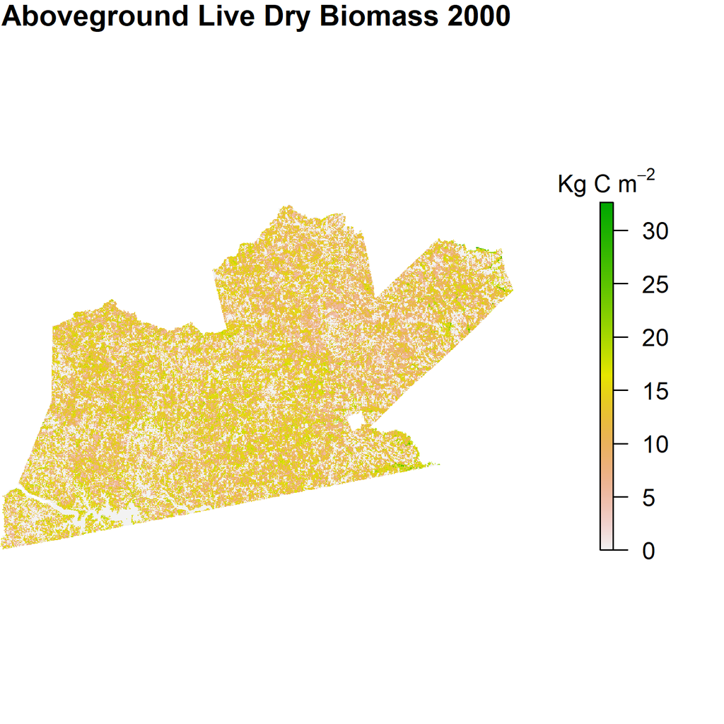

```r
# Figure 12: Aboveground woody biomass 2000 map. (NBCD dataset).
knitr::include_graphics(here('external/figures/biomass_FIA_ALD2000.png'))
```

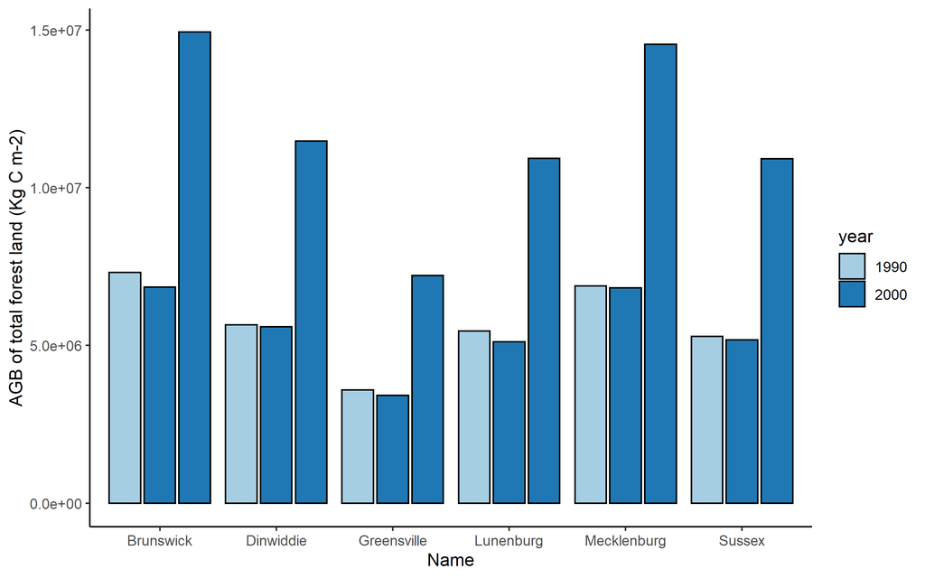

```r
# Figure 13: Bar graph of AGB for total forest land. The middle bar is from the SE forest carbon stock dataset, while the right bar is from the NBCD dataset.
knitr::include_graphics(here('external/figures/bar_agb.png'))
```

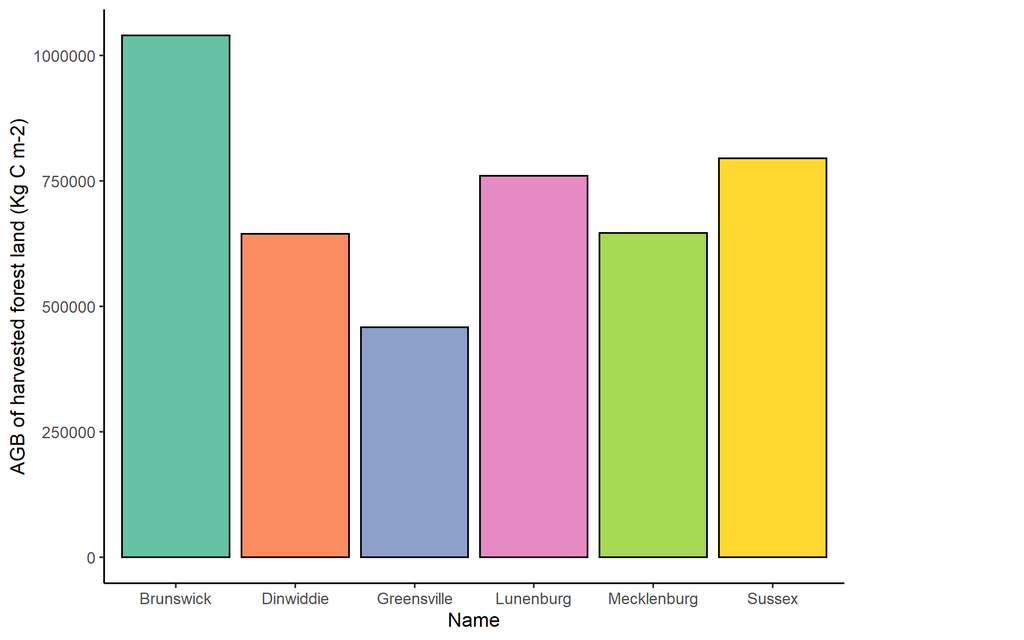

```r
# Figure 14: Bar graph of AGB lost between 1990 and 2000.
knitr::include_graphics(here('external/figures/bar_agb_harvested.png'))
```

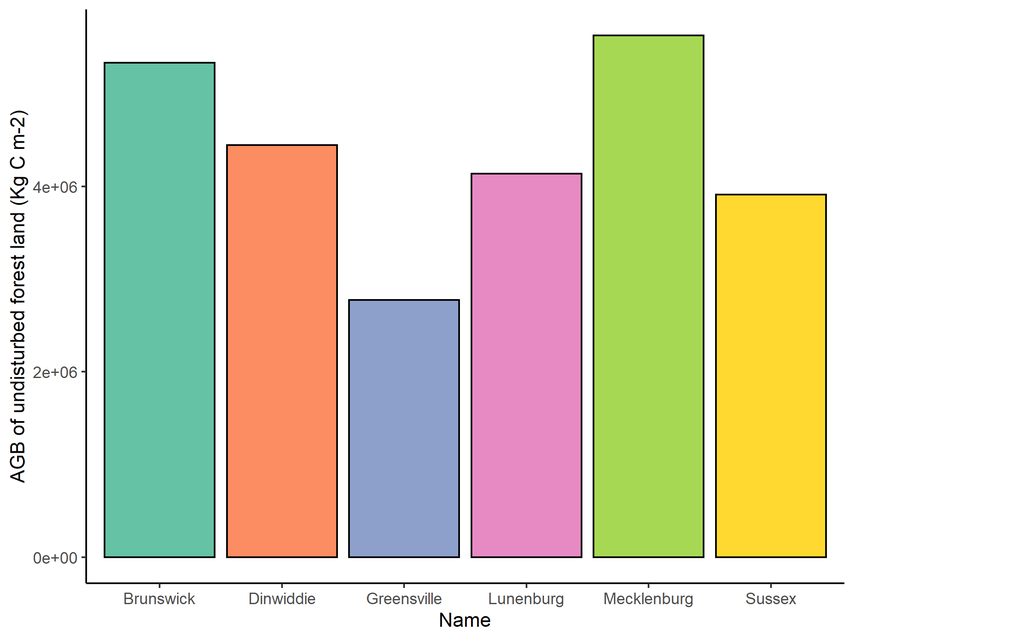

```r
# Figure 15: Bar graph of AGB undisturbed between 1990 and 2000.
knitr::include_graphics(here('external/figures/bar_agb_undisturbed.png'))
```

## 4. Discussion and conclusion.

During the forest dynamics analysis, we learnt many new packages, functions and improved our problem-solving skill. We learnt using the “here” package to locate our files relative to project root. And a “gridExtra” package to arrange our data frame and draw tables. To save our result into the png format, we used the “png” and “dev.off” function. “Knitr::include_graphics” function helped us to display our outputs in an easier way. We also tried to use Monitoring Trends in Burn Severity (MTBS) data to filter our forest cover map, but after cropping and masking the data, we found that there was no overlap between these two datasets, which means there is no burned area in our study area.

In this project, we have met many challenges and uncertainties. Jianing spent a lot of time debugging when she tried to rasterize the study area shapefile and finally found that she missed the resolution value, which reminded her of paying more attention to details. Also, she wanted to emphasize that nobody should forget to resample before using the “zonal” function. Li had trouble building and installing our group project package. She also encountered errors while uploading large files (>100 MB) onto Github. Later on, she learnt to use the “git filter-branch” function to rewrite the git history and only submit files smaller than 100 MB on Github. She also became more familiar with “devtools” after several tries of building R packages.

In order to develop this project further, we would like to explore the time series trajectories of forest clearing, carbon stock, and biomass change based on the datasets we have. We also want to learn more about the shiny and leaflet frameworks to display our project in a more data-user-friendly way. We also would like to explore the time series trajectory of forest clearing, carbon stock, and biomass change based on the datasets we have.

## 5.References

Foley, J.A., DeFries, R., Asner, G.P., Barford, C., Bonan, G., Carpenter, S.R., Chapin, F.S., Coe, M.T., Daily, G.C., Gibbs, H.K., Helkowski, J.H., Holloway, T., Howard, E.A., Kucharik, C.J., Monfreda, C., Patz, J.A., Prentice, C., Ramankutty, N., & Snyder, P.K. (2005). Global Consequences of Land Use. Science, 309, 570-574.

Hansen, M.C., Potapov, P., Moore, R., Hancher, M., Turubanova, S., Tyukavina, A., Thau, D., Stehman, S., Goetz, S., Loveland, T., Kommareddy, A., Egorov, A., Chini, L., Justice, C.O., & Townshend, J. (2013). High-Resolution Global Maps of 21st-Century Forest Cover Change. Science, 342, 850-853.

Masek, J. G., Cohen, W. B., Leckie, D., Wulder,, M. A., Vargas, R., de Jong, B., et al. (2011). Recent rates of forest harvest and conversion in North America. Journal of Geophysical Research, 116(G4), 1–22. http://dx.doi.org/10.1029/2010JG001471.

Potapov, P.V., Hansen, M.C., Laestadius, L., Turubanova, S., Yaroshenko, A., Thies, C., Smith, W., Zhuravleva, I., Komarova, A., Minnemeyer, S., & Esipova, E. (2017). The Last Frontiers of Wilderness: Tracking Loss of Intact Forest Landscapes from 2000 to 2013. Science Advances, 3, 1-13.